# REFMAP Listening test 1 analysis: Random forest variable importance identification

This notebook analyses the Part A and B data in terms of variable importance using a random forest model based on conditional inference trees and a conditional permutation variable importance algorithm.

# Setup

## Load packages

```r
# load packages
library(tidyr)
library(unikn)
library(ggplot2)
require(flexplot)
library(party)
library(randomForest)
# set package parameters
theme_set(theme_bw())
```

```r
# function to enable plot dimension adjustment
set_plot_dimensions <- function(width_choice, height_choice) {
        options(repr.plot.width=width_choice, repr.plot.height=height_choice)
        }
```

## Import data and wrangle

```r
stimDataA <- read.csv("C:\\Users\\m_lot\\OneDrive - University of Salford\\REFMAP General\\03 Experiment\\Experiment 1\\Analysis\\PostProcess\\refmap_listest1_testdataA_ByStim.csv", header=TRUE)

subjLongDataA <- read.csv("C:\\Users\\m_lot\\OneDrive - University of Salford\\REFMAP General\\03 Experiment\\Experiment 1\\Analysis\\PostProcess\\refmap_listest1_testdataA_BySubj.csv", header=TRUE)
```

```r
# function to encode categorical to ordinal variables
encode_ordinal <- function(x, order=unique(x)) {
  x <- as.numeric(factor(x, levels=order, exclude=NULL))
  x
}

# definition of ordinal variable levels
SNRCats <- c("No UAS", "-16", "-10", "-4", "2", "8")
UASLAeqCats <- c("No UAS", "42", "48", "54", "60")
```

The aggregated data by stimulus are assigned to a dataframe, relevant categorical variables are converted to ordinal, and then the variable subset of interest is selected, NA rows dropped (ie, the ‘no UAS’ stimuli, as the conditional variable importance algorithm cannot currently handle NA values, which are present in all the UAS dB metrics), and a formula assigned.

```r
stimDataANum <- stimDataA

stimDataANum[['SNRlevel']] <- encode_ordinal(stimDataA[['SNRlevel']], order=SNRCats)
stimDataANum[['UASLAeq']] <- encode_ordinal(stimDataA[['UASLAeq']], order=UASLAeqCats)

stimDataANum <- cbind(stimDataANum[, which(colnames(stimDataANum)=="UASLAeq"):
                                     which(colnames(stimDataANum)=="SNRlevel")],
                      stimDataANum[, which(colnames(stimDataANum)=="UASLAeqMaxLR"):
                                     which(colnames(stimDataANum)=="UASImpulsHMS05ExMaxLR")],
                      stimDataANum[, which(colnames(stimDataANum)=="UASLAeqdiffAmbLAF90"):
                                     which(colnames(stimDataANum)=="UASPartLoudGMSTPowAvg")],
                      stimDataANum[, which(colnames(stimDataANum)=="dTonalECMAHMSAvgMaxLR"):
                                     which(colnames(stimDataANum)=="dImpulsHMS05ExMaxLR")])
colSelect = c('ValenceMedian', 'ArousalMedian', 'AnnoyMedian', 'HighAnnoyProportion')
stimDataANum <- cbind(stimDataANum, stimDataA[, colSelect])
stimDataANum <- subset(stimDataANum, select = -c(UASLAEMaxLR))

# drop rows missing with missing values, as conditional variable importance cannot handle these
stimDataANum <- stimDataANum[complete.cases(stimDataANum),]

includeVarsStim <- names(stimDataANum)[1:which(names(stimDataANum) == 'dImpulsHMS05ExMaxLR')]
formVarStim <- reformulate(includeVarsStim, 'AnnoyMedian')
```

This process is repeated for the disaggregated data by subject.

```r
subjDataANum <- subjLongDataA

subjDataANum[['SNRlevel']] <- encode_ordinal(subjLongDataA[['SNRlevel']], order=SNRCats)
subjDataANum[['UASLAeq']] <- encode_ordinal(subjLongDataA[['UASLAeq']], order=UASLAeqCats)

subjDataANum <- cbind(subjDataANum[, which(colnames(subjDataANum)=="UASLAeq"):
                                     which(colnames(subjDataANum)=="SNRlevel")],
                      subjDataANum[, which(colnames(subjDataANum)=="UASLAeqMaxLR"):
                                     which(colnames(subjDataANum)=="UASImpulsHMSMaxMaxLR")],
                      subjDataANum[, which(colnames(subjDataANum)=="UASLAeqdiffAmbLAF90"):
                                     which(colnames(subjDataANum)=="UASPartLoudGMSTPowAvg")],
                      subjDataANum[, which(colnames(subjDataANum)=="dTonalECMAHMSAvgMaxLR"):
                                     which(colnames(subjDataANum)=="dImpulsHMS05ExMaxLR")])
colSelect = c('Valence', 'Arousal', 'Annoyance', 'HighAnnoy')
subjDataANum <- cbind(subjDataANum, subjLongDataA[, colSelect])
subjDataANum <- subset(subjDataANum, select = -c(UASLAEMaxLR))

# drop rows missing with missing values, as conditional variable importance cannot handle these
subjDataANum <- subjDataANum[complete.cases(subjDataANum),]

includeVarsSubj <- names(subjDataANum)[1:which(names(subjDataANum) == 'dImpulsHMS05ExMaxLR')]
formVarSubj <- reformulate(includeVarsSubj, 'Annoyance')
```

## Training the model

### Aggregated data

#### All variables

The random forest modelling is run on the aggregated data, including all the variables.

```r
set.seed(909)
crf_AggModel <- party::cforest(formVarStim, data=stimDataANum,
                               controls=party::cforest_unbiased(ntree=1000,
                                                                mtry=as.integer(length(includeVarsStim)/1.25)))

crf_AggModelOOB <- predict(crf_AggModel, OOB=TRUE, type='response')

# Error quantiles
round(quantile(abs(crf_AggModelOOB - data.matrix(crf_AggModel@data@env$response))), digits=3)
```

```
   0%   25%   50%   75%  100%
0.045 0.183 0.365 0.831 1.396
```

```r
cor(crf_AggModelOOB, crf_AggModel@data@env$response)^2  # Rsquared
```

```
            AnnoyMedian
AnnoyMedian   0.7203706
```

The marginal variable importance is calculated.

```r
sort(party::varimp(crf_AggModel), decreasing=TRUE)
```

```
     UASLoudECMAHMSPowAvgBin       UASLoudISO3PowAvgMaxLR                  AmbientLAeq
                4.753194e-01                 4.642023e-01                 3.656285e-01
      UASLoudISO1PowAvgMaxLR                      UASLAeq              UASEPNLNoTMaxLR
                1.863310e-01                 6.479524e-02                 5.810385e-02
             UASLAF10ExMaxLR                 UASLAeqMaxLR                  EPNLNoTdiff
                4.253338e-02                 2.297098e-02                 1.692628e-02
              UASLAFmaxMaxLR          UASLAeqdiffAmbLAF90                 UASEPNLMaxLR
                1.590728e-02                 1.287776e-02                 1.209105e-02
  dSharpAuresISO3PowAvgMaxLR         UASLoudISO105ExMaxLR               UASLASmaxMaxLR
                1.106020e-02                 5.635259e-03                 4.632241e-03
             UASLAF25ExMaxLR   UASSharpAuresISO305ExMaxLR        UASPartLoudGMSTPowAvg
                3.983818e-03                 2.945487e-03                 2.853064e-03
          dImpulsHMSAvgMaxLR         dRoughECMAHMS10ExBin         dRoughECMAHMS05ExBin
                2.579814e-03                 2.538814e-03                 1.743174e-03
    dSharpAuresISO305ExMaxLR       dTonalECMAHMS05ExMaxLR        UASLASmaxdiffAmbLAF90
                1.643587e-03                 1.636765e-03                 1.389010e-03
       dTonalECMAHMSAvgMaxLR                     SNRlevel               UASLAF5ExMaxLR
                1.151326e-03                 1.103653e-03                 9.630162e-04
         dFluctstrHMS05ExBin          dFluctstrHMS10ExBin    UASSharpAuresISO3AvgMaxLR
                7.616089e-04                 7.029511e-04                 6.209478e-04
       UASLASmaxdiffAmbLAF50                  PNLTmaxdiff              UASPNLTmaxMaxLR
                5.574996e-04                 5.400628e-04                 4.838561e-04
     dSharpAuresISO3AvgMaxLR              UASLAF95ExMaxLR         UASLASmaxdiffAmbLAeq
                4.183271e-04                 3.854161e-04                 3.514431e-04
                    EPNLdiff UASSharpAuresISO3PowAvgMaxLR              UASLAF50ExMaxLR
                3.142521e-04                 2.400154e-04                 1.922123e-04
             UASLAF90ExMaxLR          dImpulsHMS05ExMaxLR        UASFluctstrHMS10ExBin
                1.863192e-04                 1.384508e-04                 1.234430e-05
             UASLAF75ExMaxLR      UASTonalECMAHMSAvgMaxLR       UASRoughECMAHMS10ExBin
                0.000000e+00                 0.000000e+00                 0.000000e+00
     UASImpulsHMSPowAvgMaxLR         UASImpulsHMSAvgMaxLR     UASTonalECMAHMS05ExMaxLR
                0.000000e+00                 0.000000e+00                 0.000000e+00
      UASRoughECMAHMS05ExBin        dImpulsHMSPowAvgMaxLR           dImpulsHMSMaxMaxLR
                0.000000e+00                 0.000000e+00                 0.000000e+00
       UASFluctstrHMS05ExBin         UASImpulsHMSMaxMaxLR        UASImpulsHMS05ExMaxLR
               -4.281633e-06                -5.084120e-05                -7.054674e-05
```

Now, the conditional variable permutations importance is calculated.

```r
# using permimp cpi
start.time <- Sys.time()

pimpCrfAggModel <- permimp::permimp(crf_AggModel, nperm=1, conditional=TRUE,
                                    threshold=0.95, progressBar = FALSE)

end.time <- Sys.time()
time.taken <- round(end.time - start.time, 2)
time.taken
```

```
Time difference of 1.87 secs
```

```r
pimpCrfAggOrdered <- round(sort(pimpCrfAggModel$values, decreasing=F), digits=4)
rev(pimpCrfAggOrdered)
```

```
     UASLoudECMAHMSPowAvgBin                  AmbientLAeq       UASLoudISO3PowAvgMaxLR
                      0.3558                       0.3276                       0.3254
      UASLoudISO1PowAvgMaxLR                      UASLAeq              UASEPNLNoTMaxLR
                      0.1276                       0.0532                       0.0461
             UASLAF10ExMaxLR                 UASLAeqMaxLR               UASLAFmaxMaxLR
                      0.0324                       0.0212                       0.0171
                 EPNLNoTdiff          UASLAeqdiffAmbLAF90                 UASEPNLMaxLR
                      0.0149                       0.0110                       0.0088
  dSharpAuresISO3PowAvgMaxLR         UASLoudISO105ExMaxLR              UASLAF25ExMaxLR
                      0.0086                       0.0058                       0.0046
        dRoughECMAHMS10ExBin               UASLASmaxMaxLR        UASPartLoudGMSTPowAvg
                      0.0030                       0.0027                       0.0019
          dImpulsHMSAvgMaxLR       dTonalECMAHMS05ExMaxLR     dSharpAuresISO305ExMaxLR
                      0.0019                       0.0015                       0.0013
              UASLAF5ExMaxLR   UASSharpAuresISO305ExMaxLR        UASLASmaxdiffAmbLAF90
                      0.0009                       0.0009                       0.0009
             UASPNLTmaxMaxLR         dRoughECMAHMS05ExBin        dTonalECMAHMSAvgMaxLR
                      0.0008                       0.0008                       0.0007
         dFluctstrHMS10ExBin      dSharpAuresISO3AvgMaxLR                     SNRlevel
                      0.0007                       0.0006                       0.0005
             UASLAF95ExMaxLR                     EPNLdiff        UASLASmaxdiffAmbLAF50
                      0.0004                       0.0003                       0.0003
                 PNLTmaxdiff          dFluctstrHMS05ExBin              UASLAF50ExMaxLR
                      0.0003                       0.0002                       0.0002
        UASLASmaxdiffAmbLAeq        UASFluctstrHMS10ExBin              UASLAF90ExMaxLR
                      0.0001                       0.0001                       0.0001
       UASFluctstrHMS05ExBin           dImpulsHMSMaxMaxLR        dImpulsHMSPowAvgMaxLR
                      0.0000                       0.0000                       0.0000
      UASRoughECMAHMS05ExBin     UASTonalECMAHMS05ExMaxLR         UASImpulsHMSAvgMaxLR
                      0.0000                       0.0000                       0.0000
     UASImpulsHMSPowAvgMaxLR       UASRoughECMAHMS10ExBin      UASTonalECMAHMSAvgMaxLR
                      0.0000                       0.0000                       0.0000
             UASLAF75ExMaxLR        UASImpulsHMS05ExMaxLR         UASImpulsHMSMaxMaxLR
                      0.0000                       0.0000                      -0.0001
         dImpulsHMS05ExMaxLR UASSharpAuresISO3PowAvgMaxLR    UASSharpAuresISO3AvgMaxLR
                     -0.0001                      -0.0001                      -0.0001
```

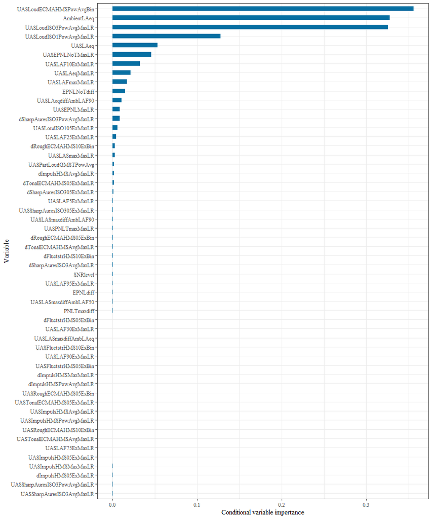

```r
par(mai=c(0,3,0,0))
pimpCrfAggOrdereddf <- data.frame(pimpCrfAggOrdered)
pimpCrfAggOrdereddf <- plyr::rename(pimpCrfAggOrdereddf, c("pimpCrfAggOrdered" = "Variable_importance"))

pBar <- ggplot(pimpCrfAggOrdereddf) + geom_col(aes(x=factor(rownames(pimpCrfAggOrdereddf), levels=rownames(pimpCrfAggOrdereddf)), y=Variable_importance), fill="#076fa2", width=0.5) + labs(x="Variable", y="Conditional variable importance") + theme(text = element_text(family = "serif"))
pBar + coord_flip()
```

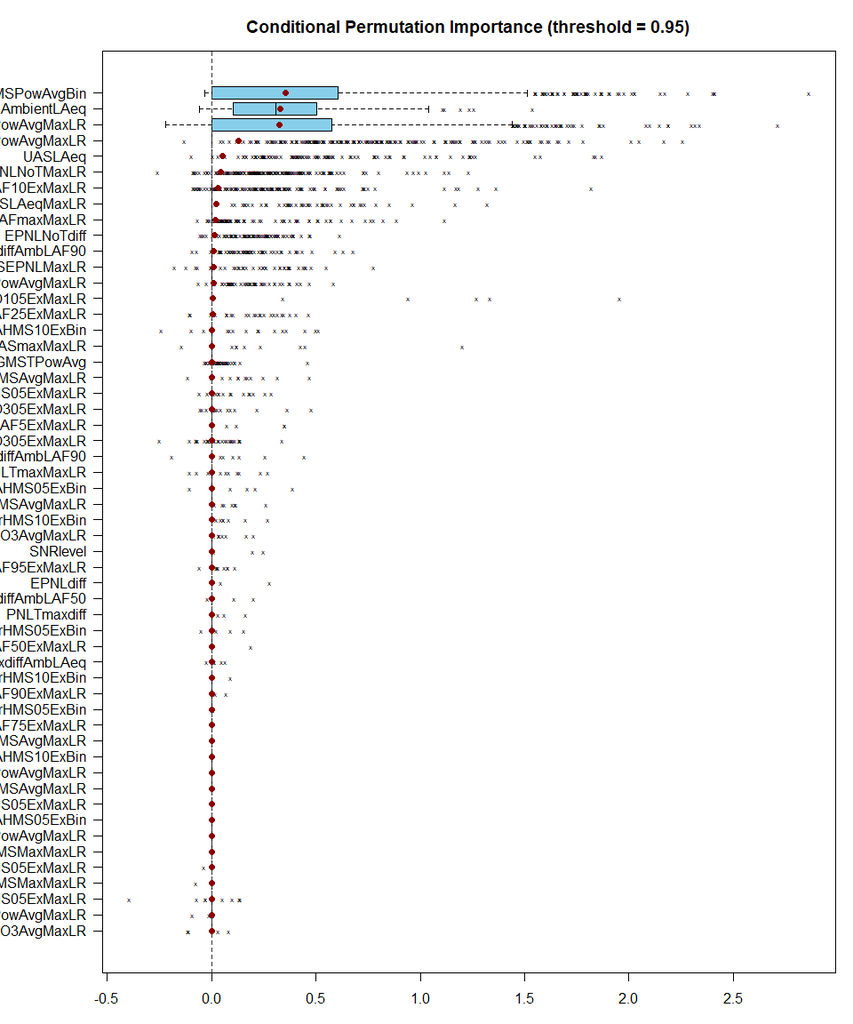

```r
# plot cpi
permimp::plot.VarImp(pimpCrfAggModel, type='box', horizontal=TRUE)
```

### Individual data

Next, a new model is run on the disaggregated data:

```r
set.seed(909)
crf_IndModel <- party::cforest(formVarSubj, data=subjDataANum,
                               controls=party::cforest_unbiased(ntree=500,
                                                                mtry=as.integer(length(includeVarsSubj)/1.25)))

crf_IndModelOOB <- predict(crf_IndModel, OOB=TRUE, type='response')

# Error quantiles
round(quantile(abs(crf_IndModelOOB - data.matrix(crf_IndModel@data@env$response))), digits=3)
```

```
   0%   25%   50%   75%  100%
0.000 0.831 1.667 2.834 7.650
```

```r
cor(crf_IndModelOOB, crf_IndModel@data@env$response)^2  # Rsquared
```

```
          Annoyance
Annoyance  0.121845
```

```r
sort(party::varimp(crf_IndModel), decreasing=TRUE)
```

```
     UASLoudECMAHMSPowAvgBin                  AmbientLAeq
                0.4687062105                 0.4581473141
                     UASLAeq       UASLoudISO3PowAvgMaxLR
                0.2436638061                 0.1380831136
             UASLAF10ExMaxLR                 UASLAeqMaxLR
                0.1004100643                 0.0930675551
         UASLAeqdiffAmbLAF90              UASEPNLNoTMaxLR
                0.0584210814                 0.0393038982
  UASSharpAuresISO305ExMaxLR                     EPNLdiff
                0.0324670326                 0.0187331822
       UASLASmaxdiffAmbLAF90        UASFluctstrHMS05ExBin
                0.0150697092                 0.0143667754
                 EPNLNoTdiff              UASLAF25ExMaxLR
                0.0141547002                 0.0140885900
  dSharpAuresISO3PowAvgMaxLR                 UASEPNLMaxLR
                0.0140151580                 0.0132682327
       UASLASmaxdiffAmbLAF50 UASSharpAuresISO3PowAvgMaxLR
                0.0107206081                 0.0105051195
              UASLAF5ExMaxLR                     SNRlevel
                0.0095240518                 0.0091313768
        UASLASmaxdiffAmbLAeq      dSharpAuresISO3AvgMaxLR
                0.0056441179                 0.0055610922
       UASFluctstrHMS10ExBin         dRoughECMAHMS10ExBin
                0.0045541458                 0.0039536667
         dFluctstrHMS10ExBin       UASLoudISO1PowAvgMaxLR
                0.0038999031                 0.0038357632
          dImpulsHMSAvgMaxLR      UASTonalECMAHMSAvgMaxLR
                0.0035830662                 0.0031204401
       UASPartLoudGMSTPowAvg       dTonalECMAHMS05ExMaxLR
                0.0028161610                 0.0024913030
       dTonalECMAHMSAvgMaxLR         UASImpulsHMSAvgMaxLR
                0.0022834642                 0.0021515413
         dImpulsHMS05ExMaxLR    UASSharpAuresISO3AvgMaxLR
                0.0019130055                 0.0011997310
              UASLAFmaxMaxLR          dFluctstrHMS05ExBin
                0.0008233676                 0.0007934570
    dSharpAuresISO305ExMaxLR         dRoughECMAHMS05ExBin
                0.0006890147                 0.0006454916
              UASLASmaxMaxLR         UASLoudISO105ExMaxLR
                0.0005173722                 0.0004307082
                 PNLTmaxdiff       UASRoughECMAHMS10ExBin
                0.0003697424                 0.0002436050
             UASLAF95ExMaxLR              UASLAF50ExMaxLR
               -0.0001122150                -0.0001550531
             UASPNLTmaxMaxLR         UASImpulsHMSMaxMaxLR
               -0.0003322351                -0.0003990356
     UASImpulsHMSPowAvgMaxLR        UASImpulsHMS05ExMaxLR
               -0.0004173223                -0.0005575059
             UASLAF90ExMaxLR              UASLAF75ExMaxLR
               -0.0006511897                -0.0006718470
       dImpulsHMSPowAvgMaxLR     UASTonalECMAHMS05ExMaxLR
               -0.0007280566                -0.0014281843
      UASRoughECMAHMS05ExBin           dImpulsHMSMaxMaxLR
               -0.0017079761                -0.0021054912
```

```r
start.time <- Sys.time()
impCrfIndModel <- permimp::permimp(crf_IndModel, nperm=1, conditional=TRUE, progressBar=FALSE)
end.time <- Sys.time()
time.taken <- round(end.time - start.time, 2)
time.taken
```

```
Time difference of 1.01 mins
```

```r
impCrfIndOrdered <- sort(impCrfIndModel$values, decreasing=F)
rev(impCrfIndOrdered)
```

```
                 AmbientLAeq           dImpulsHMSMaxMaxLR
                1.083190e-02                 8.928571e-06
         dFluctstrHMS05ExBin     UASTonalECMAHMS05ExMaxLR
                6.354190e-06                 3.124455e-06
         dImpulsHMS05ExMaxLR        dImpulsHMSPowAvgMaxLR
                0.000000e+00                 0.000000e+00
    dSharpAuresISO305ExMaxLR   dSharpAuresISO3PowAvgMaxLR
                0.000000e+00                 0.000000e+00
     dSharpAuresISO3AvgMaxLR         dRoughECMAHMS05ExBin
                0.000000e+00                 0.000000e+00
        dRoughECMAHMS10ExBin       dTonalECMAHMS05ExMaxLR
                0.000000e+00                 0.000000e+00
       dTonalECMAHMSAvgMaxLR        UASPartLoudGMSTPowAvg
                0.000000e+00                 0.000000e+00
                 PNLTmaxdiff                  EPNLNoTdiff
                0.000000e+00                 0.000000e+00
                    EPNLdiff         UASLASmaxdiffAmbLAeq
                0.000000e+00                 0.000000e+00
       UASLASmaxdiffAmbLAF50        UASLASmaxdiffAmbLAF90
                0.000000e+00                 0.000000e+00
       UASImpulsHMS05ExMaxLR   UASSharpAuresISO305ExMaxLR
                0.000000e+00                 0.000000e+00
      UASRoughECMAHMS05ExBin         UASImpulsHMSAvgMaxLR
                0.000000e+00                 0.000000e+00
     UASImpulsHMSPowAvgMaxLR UASSharpAuresISO3PowAvgMaxLR
                0.000000e+00                 0.000000e+00
   UASSharpAuresISO3AvgMaxLR       UASLoudISO3PowAvgMaxLR
                0.000000e+00                 0.000000e+00
      UASLoudISO1PowAvgMaxLR         UASLoudISO105ExMaxLR
                0.000000e+00                 0.000000e+00
      UASRoughECMAHMS10ExBin      UASTonalECMAHMSAvgMaxLR
                0.000000e+00                 0.000000e+00
     UASLoudECMAHMSPowAvgBin              UASPNLTmaxMaxLR
                0.000000e+00                 0.000000e+00
             UASEPNLNoTMaxLR               UASLASmaxMaxLR
                0.000000e+00                 0.000000e+00
             UASLAF95ExMaxLR              UASLAF90ExMaxLR
                0.000000e+00                 0.000000e+00
             UASLAF75ExMaxLR              UASLAF50ExMaxLR
                0.000000e+00                 0.000000e+00
             UASLAF25ExMaxLR              UASLAF10ExMaxLR
                0.000000e+00                 0.000000e+00
              UASLAF5ExMaxLR                 UASLAeqMaxLR
                0.000000e+00                 0.000000e+00
                    SNRlevel                      UASLAeq
                0.000000e+00                 0.000000e+00
         UASLAeqdiffAmbLAF90               UASLAFmaxMaxLR
               -4.059979e-07                -6.478782e-07
          dImpulsHMSAvgMaxLR         UASImpulsHMSMaxMaxLR
               -4.355505e-06                -6.027136e-06
         dFluctstrHMS10ExBin        UASFluctstrHMS10ExBin
               -8.030990e-06                -1.533065e-05
                UASEPNLMaxLR        UASFluctstrHMS05ExBin
               -3.156793e-05                -3.534923e-05
```

```r
par(mai=c(0,3,0,0))
impCrfIndOrdereddf <- data.frame(impCrfIndOrdered)
impCrfIndOrdereddf <- plyr::rename(impCrfIndOrdereddf, c("impCrfIndOrdered" = "Variable_importance"))

pBar <- ggplot(impCrfIndOrdereddf) + geom_col(aes(x=factor(rownames(impCrfIndOrdereddf), levels=rownames(impCrfIndOrdereddf)), y=Variable_importance), fill="#076fa2", width=0.5) + labs(x="Variable") + theme(text = element_text(family = "serif"))
pBar + coord_flip()
```

[output not shown]

Run again, omitting AmbientLAeq variable

```r
includeVarsSubj <- c(names(subjDataANum)[1], names(subjDataANum)[3:which(names(subjDataANum) == 'dImpulsHMS05ExMaxLR')])
formVarSubj <- reformulate(includeVarsSubj, 'Annoyance')

set.seed(909)
crf_IndModel <- party::cforest(formVarSubj, data=subjDataANum[, !(names(subjDataANum) %in% "AmbientLAeq")],
                               controls=party::cforest_unbiased(ntree=500,
                                                                mtry=as.integer(length(includeVarsSubj)/1.25)))

crf_IndModelOOB <- predict(crf_IndModel, OOB=TRUE, type='response')

# Error quantiles
round(quantile(abs(crf_IndModelOOB - data.matrix(crf_IndModel@data@env$response))), digits=3)
```

```
   0%   25%   50%   75%  100%
0.000 0.839 1.662 2.827 7.613
```

```r
cor(crf_IndModelOOB, crf_IndModel@data@env$response)^2  # Rsquared
```

```
          Annoyance
Annoyance  0.121976
```

```r
start.time <- Sys.time()
impCrfIndModel <- permimp::permimp(crf_IndModel, nperm=1, conditional=TRUE, progressBar=FALSE)
end.time <- Sys.time()
time.taken <- round(end.time - start.time, 2)
time.taken
```

```
Time difference of 1.03 mins
```

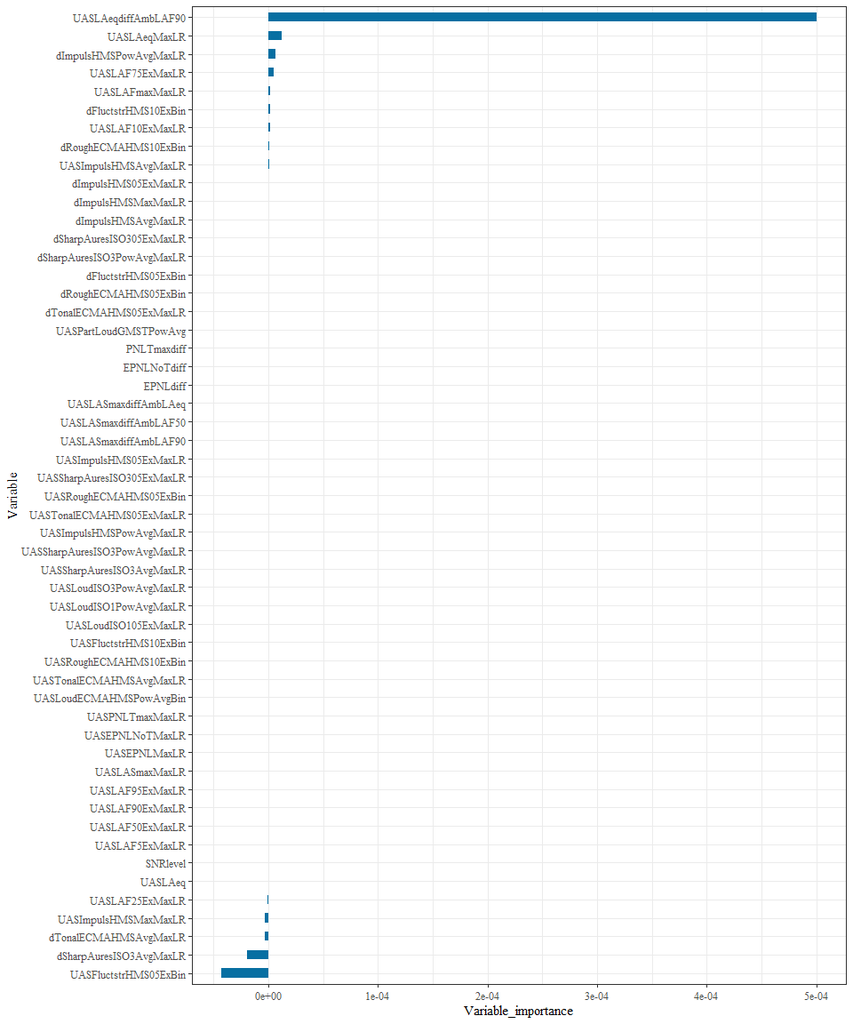

```r
impCrfIndOrdered <- sort(impCrfIndModel$values, decreasing=F)
par(mai=c(0,3,0,0))
impCrfIndOrdereddf <- data.frame(impCrfIndOrdered)
impCrfIndOrdereddf <- plyr::rename(impCrfIndOrdereddf, c("impCrfIndOrdered" = "Variable_importance"))

pBar <- ggplot(impCrfIndOrdereddf) + geom_col(aes(x=factor(rownames(impCrfIndOrdereddf), levels=rownames(impCrfIndOrdereddf)), y=Variable_importance), fill="#076fa2", width=0.5) + labs(x="Variable") + theme(text = element_text(family = "serif"))
pBar + coord_flip()
```